# Concentration of NIH R01 Grants

## A Follow-Up to Bill Gardner's Post

[Bill Gardner](http://theincidentaleconomist.com/wordpress/as-health-research-funding-declines-are-the-rich-growing-richer/) worries about concentration of R01 grants and worries this may be bad for several reasons, political and scientific. The worry is timely because, in negative NIH funding growth environments, concentration might increase. We have the first part:

[figure not shown]

...so the question is primarily about concentration.

Trivially, there's some sort of visible correlation. Gardner included this graph:

[figure not shown]

With the note that:

> The vertical axis is the change from 2010 to 2013 in the proportion of graphs held by the institution. The folks at grantome.com interpret this as showing that the rich are getting richer.

> You have probably noticed a problem with this graph. To show that the rich are growing richer, grantome.com ought to have looked at whether the proportion of grants held in 2010, not 2013, was associated with the change from 2010 to 2013.

Let's check!

Data come from the NIH's [ExPORTER tool](http://exporter.nih.gov/), with documentation [here](http://exporter.nih.gov/about.aspx).

### 2010 and 2013 Concentration and Growth

Per the documentation linked above, we want only R01 grants, which is a type indicated in the 'ACTIVITY' field of the data.

```python
import pandas as pd
import numpy as np
import matplotlib.pyplot as plt
import matplotlib.image as mplimg
%pylab inline

def load_ExPORTER(year): #really don't want to type these things a thousand times
    tp = pd.read_csv('RePORTER_PRJ_C_FY{0}.csv'.format(year),
                     iterator = True,
                     chunksize = 1000)
    data = pd.concat(tp)
    data = data[data['ACTIVITY'] == 'R01']
    data['YEAR'] = year
    return data

df_2010 = load_ExPORTER(2010)
df_2013 = load_ExPORTER(2013)
```

Next, we want counts for each institution in 2010. We could restrict this to the top $x$, but won't bother to do so, because memory is cheap and these data are small.

```python
counts_2010 = df_2010['ACTIVITY'].groupby(df_2010['ORG_NAME']).count()
props_2010 = counts_2010 / counts_2010.sum()
props_2010.name = '2010 Grant Proportion'
props_2010.head()
```

```
ORG_NAME
AARHUS UNIVERSITY HOSPITAL             0.000031
AARON DIAMOND AIDS RESEARCH CENTER     0.000252
ACADEMY FOR EDUCATIONAL DEVELOPMENT    0.000031
AERAS GLOBAL TB VACCINE FOUNDATION     0.000031
AFASCI, INC.                           0.000063
Name: 2010 Grant Proportion, dtype: float64
```

```python
counts_2013 = df_2013['ACTIVITY'].groupby(df_2013['ORG_NAME']).count()
counts_2013 = counts_2013[counts_2010.index]
counts_2013.dropna(inplace=True)
counts_2010 = counts_2010[counts_2013.index]
props_2010 = props_2010[counts_2013.index]

len(counts_2013), len(counts_2010)
```

```
(602, 602)
```

Next, calculate average annual growth.

```python
growth_rates = np.exp((np.log(counts_2013) - np.log(counts_2010))/3) - 1
growth_rates.name = 'Annual Growth Rate'
growth_rates.head()
```

```
ORG_NAME
AARON DIAMOND AIDS RESEARCH CENTER     0.000000
ALBANY COLLEGE OF PHARMACY             0.000000
ALBANY MEDICAL COLLEGE                -0.176321
ALBANY RESEARCH INSTITUTE, INC.        0.000000
ALBERT EINSTEIN COLLEGE OF MEDICINE   -0.058433
Name: Annual Growth Rate, dtype: float64
```

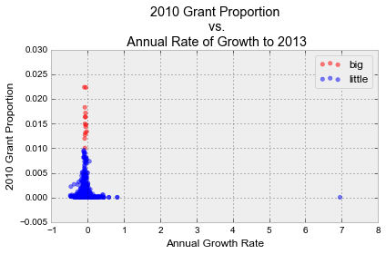

```python
plot_df = pd.DataFrame([props_2010, growth_rates]).T
plot_df['big'] = pd.Series()
plot_df['big'][plot_df['2010 Grant Proportion'] > 0.01] = 'Big'
plot_df['big'] = plot_df['big'].fillna('Little')

ax = plt.subplot(111)
ax.scatter(x = plot_df['Annual Growth Rate'][plot_df['big'] == 'Big'],
        y = plot_df['2010 Grant Proportion'][plot_df['big'] == 'Big'],
        label = 'big',
        color = 'r',
        alpha = 0.5)
ax.scatter(x = plot_df['Annual Growth Rate'][plot_df['big'] == 'Little'],
        y = plot_df['2010 Grant Proportion'][plot_df['big'] == 'Little'],
        label = 'little',
        color = 'b',
        alpha = 0.5)
ax.set_title('2010 Grant Proportion\n vs. \n Annual Rate of Growth to 2013')
ax.set_xlabel('Annual Growth Rate')
ax.set_ylabel('2010 Grant Proportion')
ax.legend(loc = 'upper right')
plt.tight_layout()
plt.savefig('plots/grantome_check2010.png')
ax
```

...and there goes the correlation. 10 house points from grantome for missing likely reverse causality. *Of course* organizations that had the largest annual rates of growth in grants from 2010 to 2013 would have higher proportions of grants in 2013.

### Checking in Each Year

But Grantome might have gotten unlucky. We can turn the above into a method that will check, for any two years (we'll always pick years that were three years apart out of fidelity to Grantome's original claim), plot the proportion of grants in the base year against the 3 year rate of growth.

For this, we need a method that takes two years as input, loads in the two relevant files, does the above formatting, and then plots the files.

```python
def check_size_v_growth(year1, year2):
    df1 = load_ExPORTER(year1) #data reads
    df2 = load_ExPORTER(year2)

    counts1 = df1['ACTIVITY'].groupby(df1['ORG_NAME']).count() #counts for year1 R01 grants
    props1 = counts1 / counts1.sum()
    props1.name = '{0} Grant Proportion'.format(year1)

    counts2 = df2['ACTIVITY'].groupby(df2['ORG_NAME']).count() #counts for year2 R01 grants
    counts2 = counts2[counts1.index]
    counts2.dropna(inplace=True)
    counts1 = counts1[counts2.index] #ensures both have the same index
    props1 = props1[counts2.index] #ensures props also has the same index

    growth_rates = np.exp((np.log(counts2) - np.log(counts1))/(year2 - year1)) - 1 #calculates annual growth rates
    growth_rates.name = 'Annual Growth Rate'

    return pd.DataFrame([growth_rates, props1]).T

def grantome_plot(data, ax = None): #assumes three years of growth, but could be modified not to make this assumption

    year_col = [c for c in data.columns if 'Proportion' in c][0] #extracts year information from data
    year = int(data[year_col].name[:4])
    data['big'] = (data['{0} Grant Proportion'.format(year)] > 0.01).map({True: 'Big', False: 'Little'}) #tags the big ones
                                                                                                         #in the first year
    if ax is None: #tries to set up different behavior depending on whether axis is present or not
        ax = plt.subplot(111)
        ax.set_title('{0} Grant Proportion\n vs. \n Annual Rate of Growth to {1}'.format(year, year + 3)) #cosmetics
        ax.set_xlabel('Annual Growth Rate') #more cosmetics
        ax.set_ylabel('Grant Proportion'.format(year))
        flag = True
    else:
        ax.set_title('{0}'.format(year), fontsize = 10)
        flag = False

    ax.scatter(x = data['Annual Growth Rate'][data['big'] == 'Big'], #scatter for big ones in red
            y = data['{0} Grant Proportion'.format(year)][data['big'] == 'Big'],
            label = 'big',
            color = 'r',
            alpha = 0.5)
    ax.scatter(x = data['Annual Growth Rate'][data['big'] == 'Little'], #scatter for little ones in blue
            y = data['{0} Grant Proportion'.format(year)][data['big'] == 'Little'],
            label = 'little',
            color = 'b',
            alpha = 0.5)

    ax.set_xlim((-1,5))
    ax.set_ylim((0,0.030))

    if flag:
        ax.legend(loc = 'upper right')
        plt.tight_layout()
        plt.savefig('plots/grantome_check{0}.png'.format(year),
                    bbox_inches = 'tight',
                    pad_inches = 0.1)
        plt.clf()
        return
    ax.set_xticklabels([])
    ax.set_yticklabels([])
```

With the above set up, we can run through many years quickly and see whether there's ever been any relationship between size and growth since ExPORTER has tracked data (1985 - 2013). We can look at these individually or, because I like grids, in a grid. Because 25 is a much more gridable number than 26, I'll look at each year from 1986 to 2010.

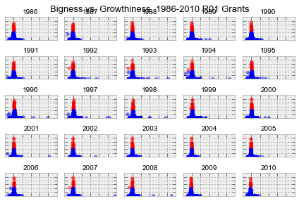

```python
fig, axes = plt.subplots(nrows = 5,
                         ncols = 5)

#do this OR the next loop
#for year in range(1986,2011):
#    data = check_size_v_growth(year, year + 3)
#    grantome_plot(data)

for i in range(5):
    for j in range(5):
        year = 1986 + i * 5 + j
        data = check_size_v_growth(year, year + 3)
        grantome_plot(data, axes[i][j])

fig.text(x = 0.5,
         y = 0.98,
         s = 'Bigness vs. Growthiness, 1986-2010 R01 Grants',
         ha = 'center',
         fontsize = 13)

plt.tight_layout()
plt.savefig('plots/grid.png', fontsize = 14, y = 1)
```